# Data AnalysisHb17052016

Hendrik Bruns

17052016

# Descriptive Statistics

Following are relevant aggregated statistics and statistics by each of the 11 treatments for each of three relevant dependent variables. These relevant dependent variables are 1. Donation, which is the amount the subject donated in order to retire emission rights 2. Donated, which is equal to 1 if the subject donated a positive amount, and 0 otherwise 3. Belief, which is the amount the subject thinks other participants in this experiment donated on average (not incentivized)

## Variable: Donation to retire carbon licenses

### Aggregated descriptive statistics

```
##    Min. 1st Qu.  Median    Mean 3rd Qu.    Max.
##   0.000   0.000   1.000   1.442   2.000   7.000
```

```
## [1] 1.544451
```

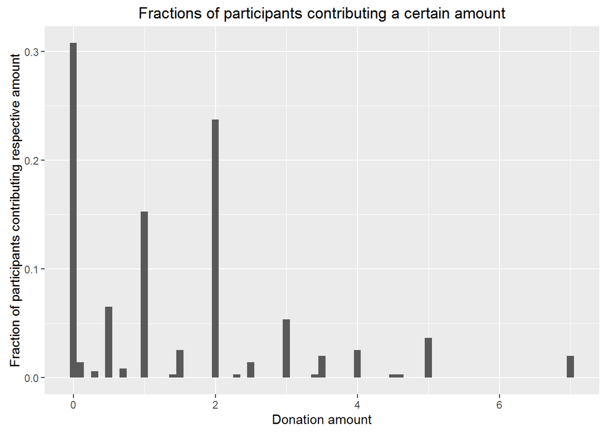

### Distribution of aggregated donations

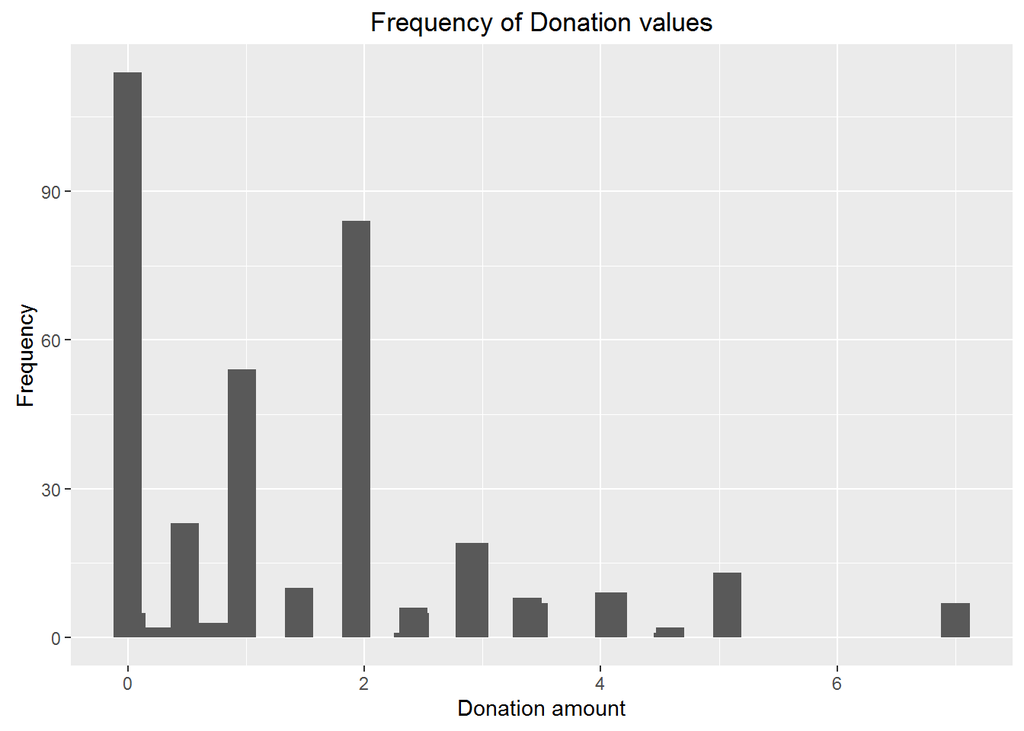

### Distribution of aggregated donations with normal curve

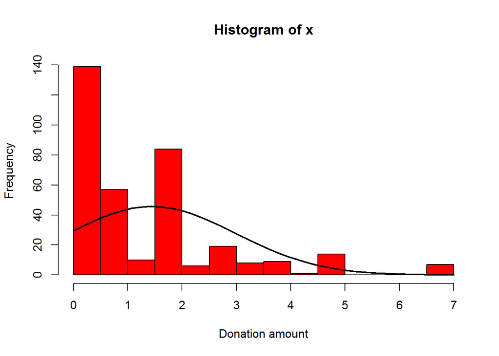

### Kernel density plot of aggregated donations

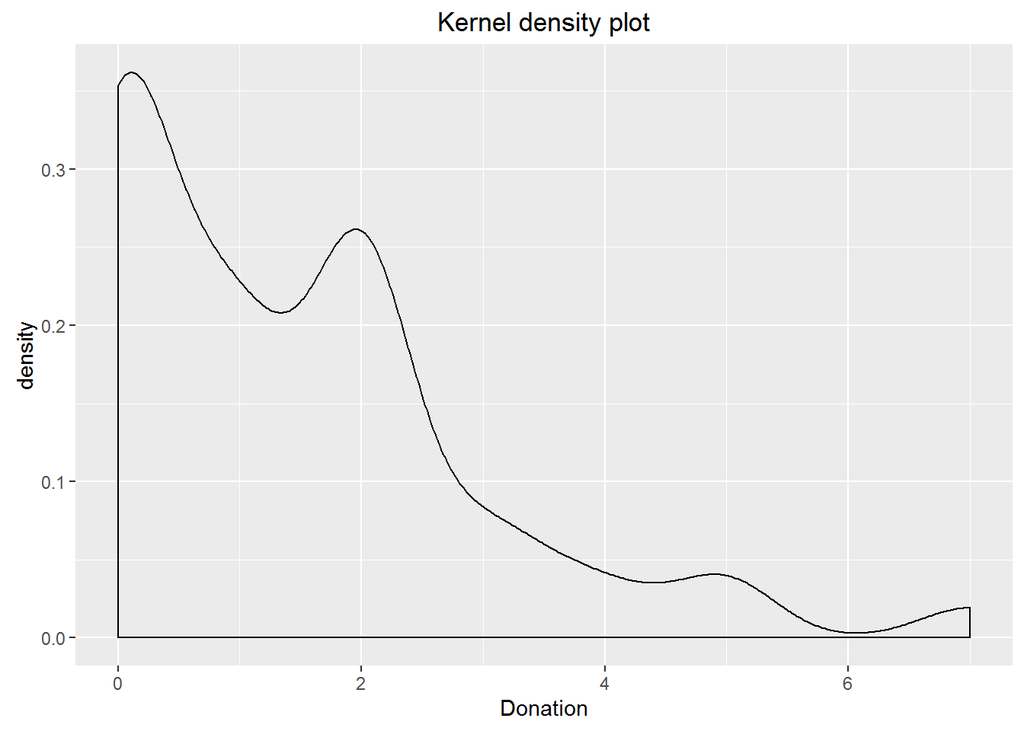

#### Distribution of donations by treatment

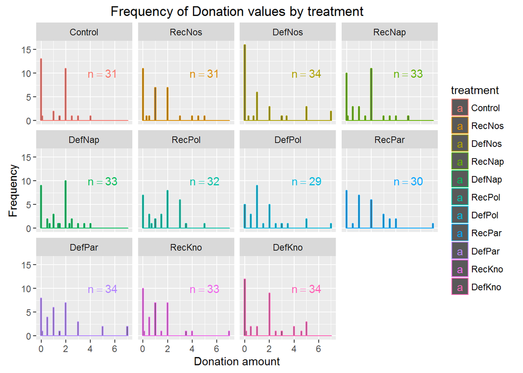

### Donations by treatment (Boxplot)

*Red diamonds in boxplots represent the respective means*

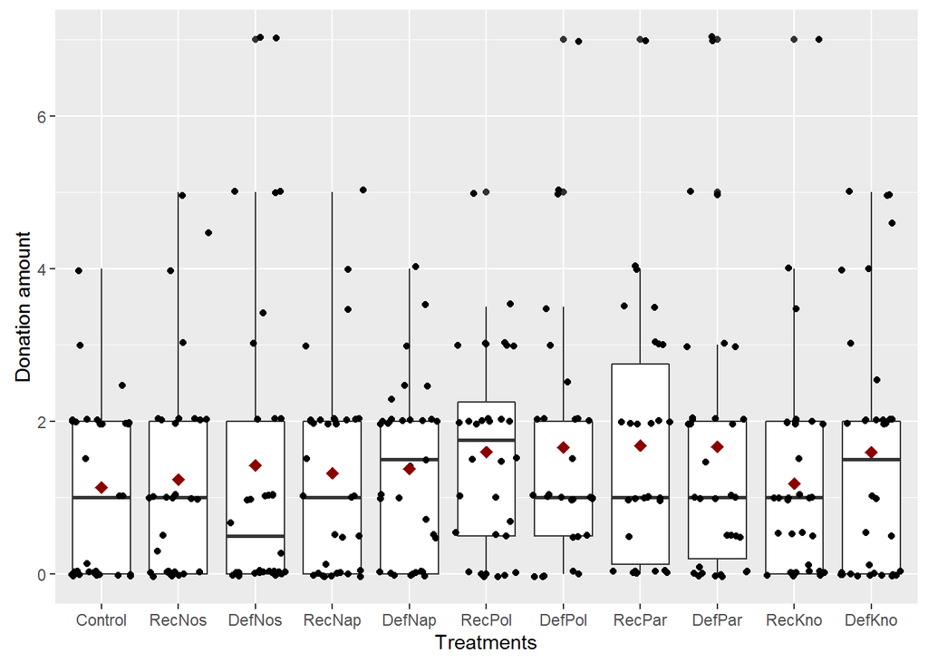

*There do not appear to be big differences in the median donations between the different treatments. Differences in mean donations, which also d not appear to be pretty big, seem to be largely driven by outliers.*

```r
kruskal.test(df$Donation ~ df$treatment)
```

```
##
##  Kruskal-Wallis rank sum test
##
## data:  df$Donation by df$treatment
## Kruskal-Wallis chi-squared = 7.434, df = 10, p-value = 0.6839
```

*The Kruskal Wallis test does not reject the null hypothesis of no differences in donations between treatments.*

### Donations by aggregated treatment (Boxplot), i.e. Def vs. Rec vs. Control

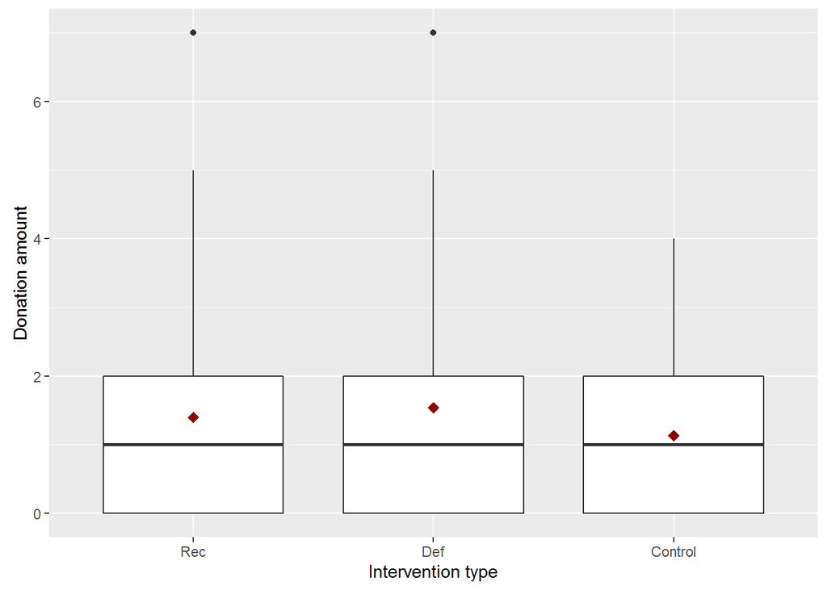

*Aggregated over all different types of sources, there appears to be no difference between donations, when the intervention is a recommendation vs. when the intervention is a default. Furthermore, both seem not to be significantly different from the control group, especially when considering that the higher means in the recommendation and default groups are likely due to outliers.*

```
##
##  Kruskal-Wallis rank sum test
##
## data:  df$Donation and df$RecvsDef
## Kruskal-Wallis chi-squared = 0.81529, df = 2, p-value = 0.6652
```

*The Kruskal Wallis test does not reject the null hypothesis of no differences in donations between recommendation, default, and control groups, irrespective of the source of intervention.*

### Donations by Reactance score

The reactance score was constructed by changing each of the 11 rectance-items to a dummy variable equal to 1 if the subject chose 3 or 4 on the respective item, and 0 otherwise. Afterwards, all 11 dummies were added to construct an ordinal Reactance score.

Shows a point plot (not jittered) with Donation amount and the respective Reactance score of each participant. Includes a linear regression line, including the 95% confidence region, of the Reactance score as a predictor for the Donation amount.

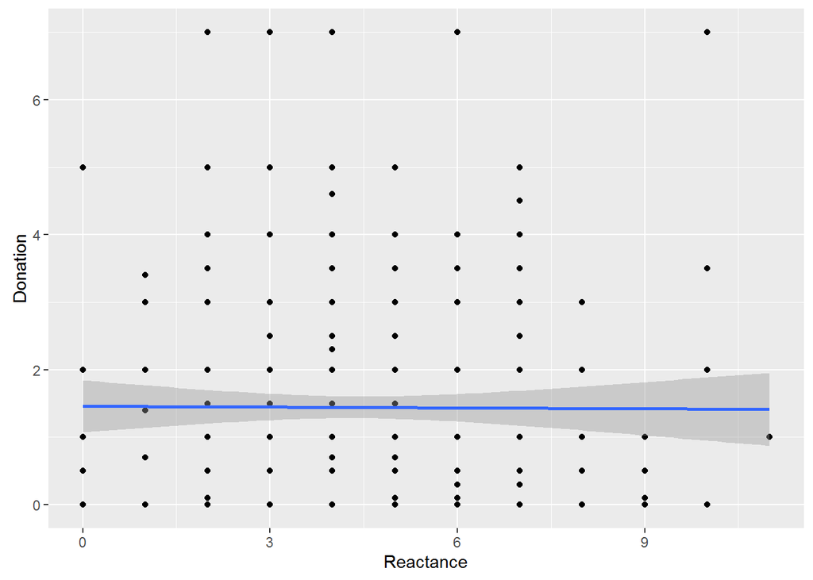

*Irrespective of treatments (i.e. assuming that reactance scores are randomly distributed over different treatments (no correlation)) there is no (linear) relationship between donation amount and reactance score.*

#### Donations by Reactance score per treatment

Shows a point plot (not jittered) with Donation amount and the respective Reactance score of each participant, for each treatment. Includes a linear regression line, including the 95% confidence region, of the Reactance score as a predictor for the Donation amount, for each treatment.

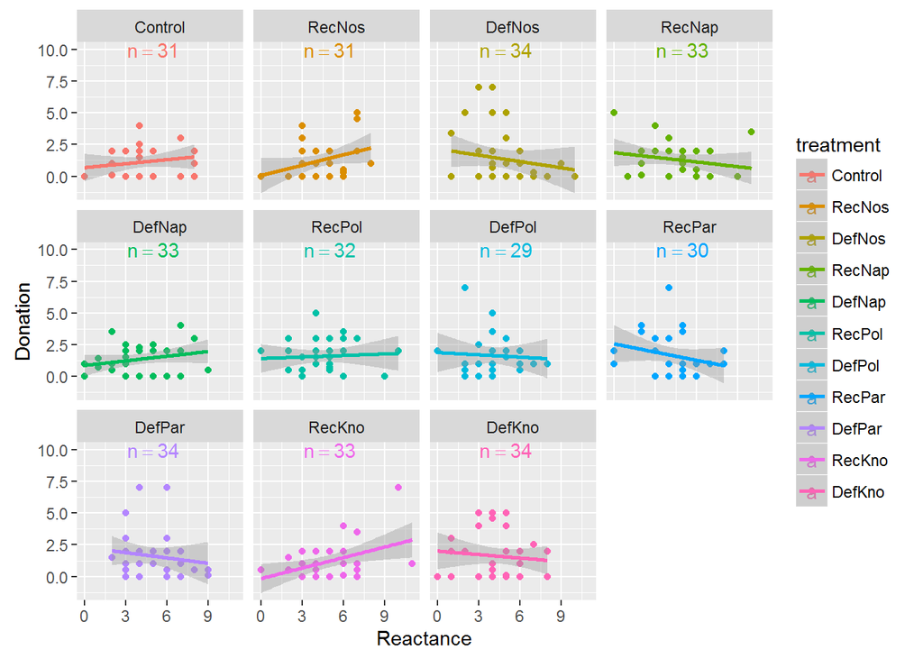

```
##
##  Kruskal-Wallis rank sum test
##
## data:  df$Reactance and df$treatment
## Kruskal-Wallis chi-squared = 5.0879, df = 10, p-value = 0.8852
```

*The Kruskal Wallis test does not reject the null hypothesis that there is no difference between the reactance scores in the different treatment groups. The plots show that there does not seem to be a consistent relationship between donation amount and reactance score over the different treatments. Judging by the graphical representation of the 95% confidence interval of the regression line, reactance score (treated as a metric) seems to be a bad predictor for donation amount, even when controlling for treatments.* *This becomes apparent in the following regression (With heteroskedasticity robust standard errors).*

```
##
## t test of coefficients:
##
##                   Estimate Std. Error t value  Pr(>|t|)
## (Intercept)      1.1446065  0.2717077  4.2126 3.232e-05 ***
## treatmentRecNos  0.1034143  0.3251236  0.3181    0.7506
## treatmentDefNos  0.2921585  0.4153815  0.7033    0.4823
## treatmentRecNap  0.1898881  0.3090044  0.6145    0.5393
## treatmentDefNap  0.2431939  0.2861361  0.8499    0.3960
## treatmentRecPol  0.4683605  0.3079530  1.5209    0.1292
## treatmentDefPol  0.5222545  0.3734481  1.3985    0.1629
## treatmentRecPar  0.5509025  0.3650960  1.5089    0.1322
## treatmentDefPar  0.5337647  0.3862027  1.3821    0.1678
## treatmentRecKno  0.0544100  0.3238505  0.1680    0.8667
## treatmentDefKno  0.4631765  0.3598920  1.2870    0.1990
## Reactance       -0.0029222  0.0419002 -0.0697    0.9444
## ---
## Signif. codes:  0 '***' 0.001 '**' 0.01 '*' 0.05 '.' 0.1 ' ' 1
```

### Donations by EAI score

The EAI score was constructed by changing each of the 12 EAI-items to a dummy variable equal to 1 if the subject chose 3 or 4 on the respective item, and 0 otherwise. Afterwards, all 12 dummies were added to construct an ordinal EAI score.

Shows a point plot (not jittered) with Donation amount and the respective EAI score of each participant. Includes a linear regression line, including the 95% confidence region, of the EAI score as a predictor for the Donation amount.

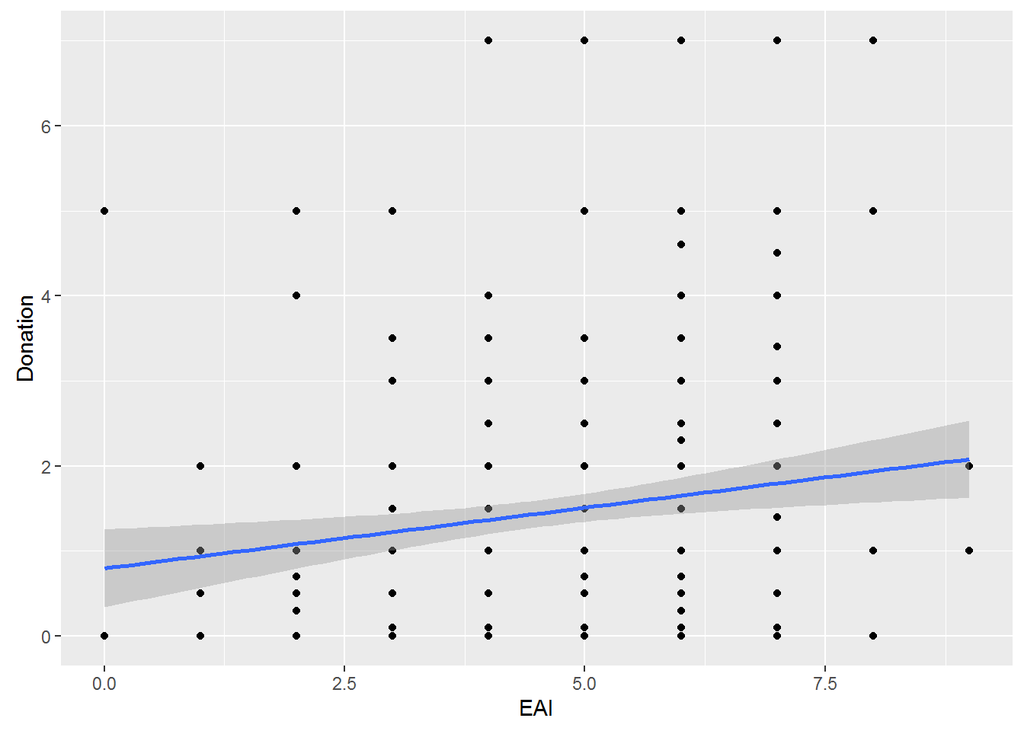

*Irrespective of treatments (i.e. assuming that EAI scores are randomly distributed over different treatments (no correlation)) there appears to be a slightly positive relationship between EAI and Donation amount. Mind, however, that, since EAI was surveyed after the experiment, it is not undoubtedly sure that there is a causal relationship. We would need to assume that Donations do not influence responses to the EAI. In any case, EAI score can be regarded as a predictor of Donation amount (irrespective of treatments), that appears to be slightly positive.*

#### Donations by EAI score per treatment

[output not shown]

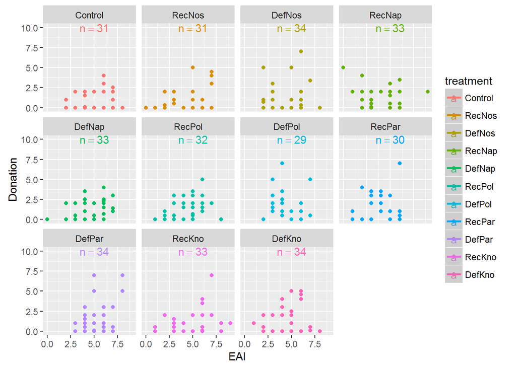

```
##
##  Kruskal-Wallis rank sum test
##
## data:  df$EAI and df$treatment
## Kruskal-Wallis chi-squared = 15.161, df = 10, p-value = 0.1263
```

```
##
## t test of coefficients:
##
##                 Estimate Std. Error t value Pr(>|t|)
## (Intercept)     0.388356   0.322940  1.2026 0.229977
## treatmentRecNos 0.234503   0.315919  0.7423 0.458423
## treatmentDefNos 0.343610   0.412755  0.8325 0.405719
## treatmentRecNap 0.320820   0.312275  1.0274 0.304975
## treatmentDefNap 0.297719   0.278673  1.0683 0.286118
## treatmentRecPol 0.538091   0.302756  1.7773 0.076406 .
## treatmentDefPol 0.549572   0.382673  1.4361 0.151876
## treatmentRecPar 0.722221   0.374111  1.9305 0.054372 .
## treatmentDefPar 0.504991   0.373163  1.3533 0.176863
## treatmentRecKno 0.079406   0.321876  0.2467 0.805291
## treatmentDefKno 0.514199   0.356688  1.4416 0.150332
## EAI             0.150725   0.053133  2.8368 0.004829 **
## ---
## Signif. codes:  0 '***' 0.001 '**' 0.01 '*' 0.05 '.' 0.1 ' ' 1
```

## Variable: Donation dummy (1 if donated, 0 otherwise)

### Aggregated descriptive statistics

```
## Not donated     Donated
##         109         245
```

```
##
##               Control RecNos DefNos RecNap DefNap RecPol DefPol RecPar
##   Not donated      13     11     16     10      9      7      5      8
##   Donated          18     20     18     23     24     25     24     22
##
##               DefPar RecKno DefKno
##   Not donated      8     10     12
##   Donated         26     23     22
```

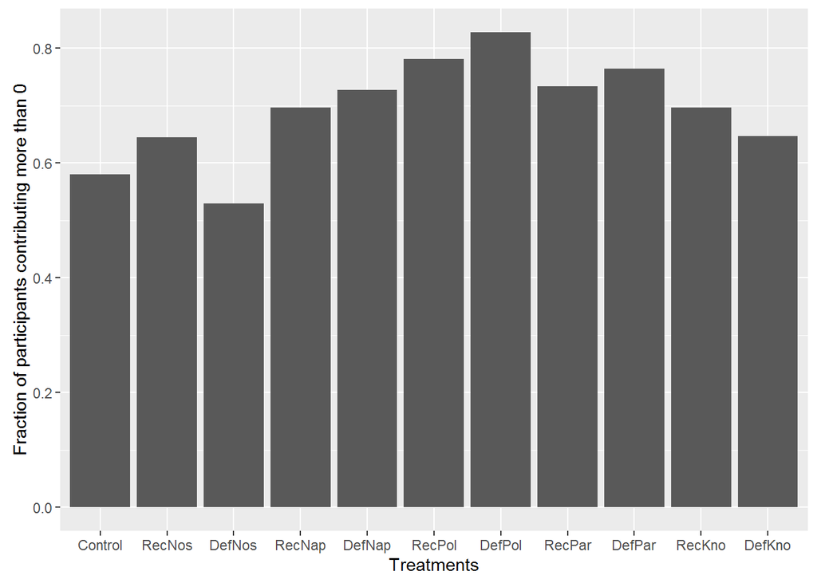

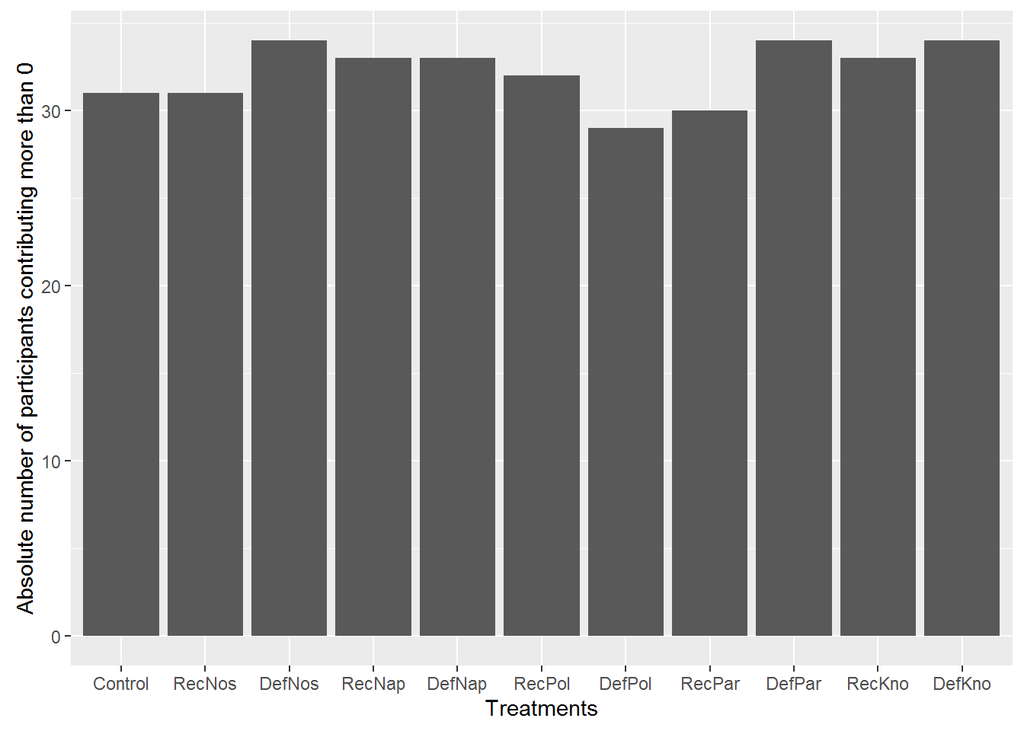

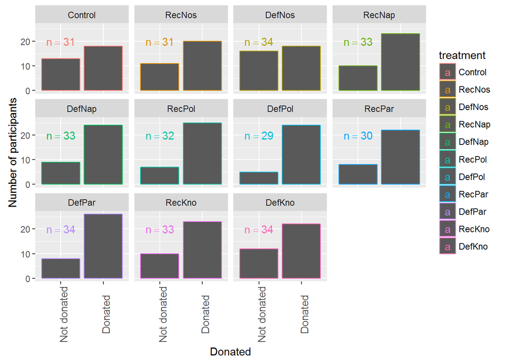

```
##
##  Pearson's Chi-squared test
##
## data:  df$Donated and df$treatment
## X-squared = 11.645, df = 10, p-value = 0.3095
```

```
##
## z test of coefficients:
##
##                 Estimate Std. Error z value Pr(>|z|)
## (Intercept)      0.32542    0.36977  0.8801  0.37882
## treatmentRecNos  0.27241    0.53118  0.5128  0.60806
## treatmentDefNos -0.20764    0.50850 -0.4083  0.68302
## treatmentRecNap  0.50749    0.53367  0.9509  0.34164
## treatmentDefNap  0.65541    0.54259  1.2079  0.22708
## treatmentRecPol  0.94754    0.57048  1.6610  0.09672 .
## treatmentDefPol  1.24319    0.62140  2.0006  0.04543 *
## treatmentRecPar  0.68618    0.55915  1.2272  0.21975
## treatmentDefPar  0.85323    0.55266  1.5439  0.12262
## treatmentRecKno  0.50749    0.53367  0.9509  0.34164
## treatmentDefKno  0.28071    0.51927  0.5406  0.58879
## ---
## Signif. codes:  0 '***' 0.001 '**' 0.01 '*' 0.05 '.' 0.1 ' ' 1
```

```
##
## z test of coefficients:
##
##                                       Estimate Std. Error z value Pr(>|z|)
## (Intercept)                            0.59784    0.38133  1.5678   0.1169
## RecvsDefDDef                          -0.48005    0.51695 -0.9286   0.3531
## SourcetypeNameAndPicture               0.23507    0.54173  0.4339   0.6643
## SourcetypeKnowledgeable                0.23507    0.54173  0.4339   0.6643
## SourcetypePolitical                    0.67513    0.57802  1.1680   0.2428
## SourcetypePartisan                     0.41376    0.56684  0.7299   0.4654
## RecvsDefDDef:SourcetypeNameAndPicture  0.62797    0.75694  0.8296   0.4068
## RecvsDefDDef:SourcetypeKnowledgeable   0.25328    0.74041  0.3421   0.7323
## RecvsDefDDef:SourcetypePolitical       0.77570    0.83984  0.9236   0.3557
## RecvsDefDDef:SourcetypePartisan        0.64711    0.78219  0.8273   0.4081
```

*According to the Chi²-test, the difference between treatments concerning the decision to donate is not significant.* *However, according to the binomial logistic regression with robust standard errors, a recommendation from a political actor, as well as a default from a political actor, significantly increase the probability to donate (p < .1 and p < .05, respectively). This effect is not visible when the logistic model is specified using the two factors intervention type and source separately with an interaction term. This indicates that the significant differences are due to differences from the control group (note that I tested whether this is true. I incorporated a treatment variable without the control group in another regression. This OLS regression had the same output as the avove regression with the interaction of Sourcetype and intervention type. However, from both I get different information. The information in the interaction model is a bit more disaggregated, since it does not evaluate effects against one treatment as the base category, but separates between intervention type, sourcetype and interaction- and main effects).*

*The following graphs visually support the regression finding of no significant influence of intervention type on extensive margins.* *Note, however, that the regressions exclude the control group.*

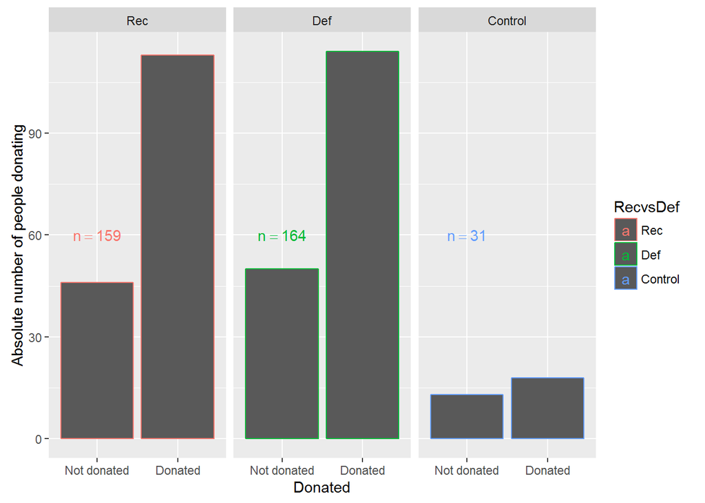

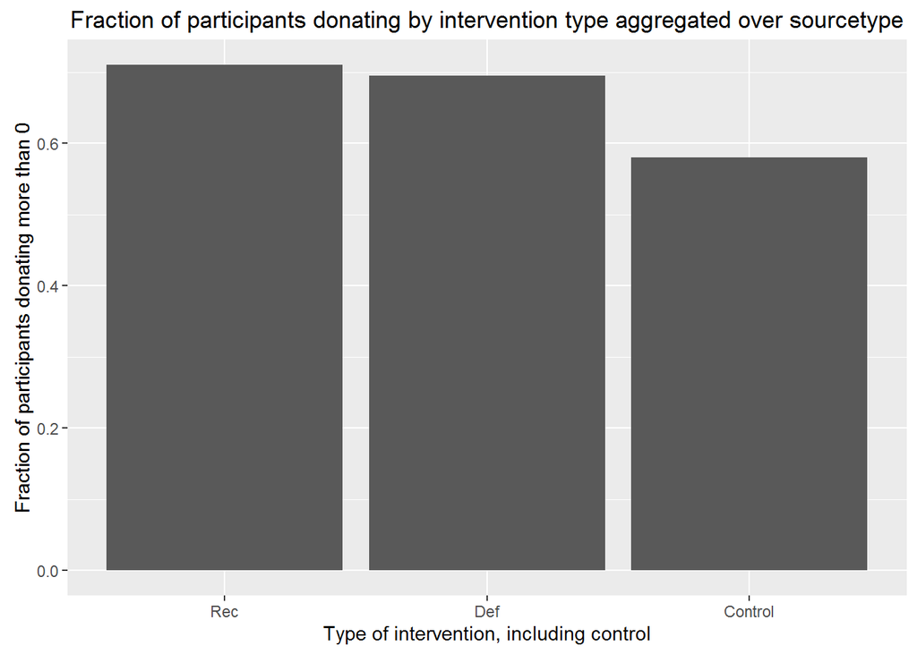

*The following graphs support the finding that sourcetype plays a (limited) role on the extensive margin, i.e. the decision to donate more than zero.*

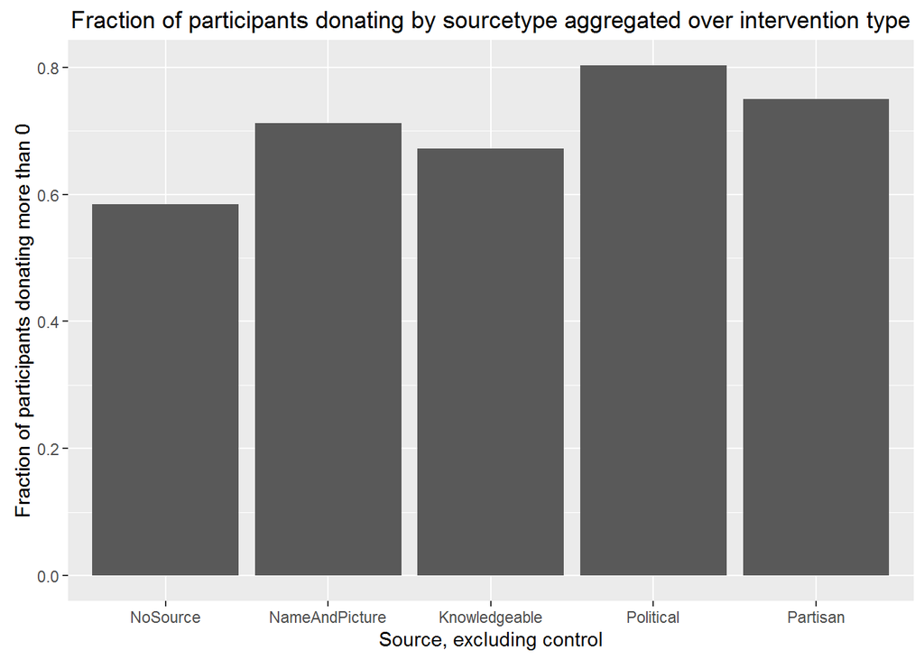

### Decision to donate by Reactance score

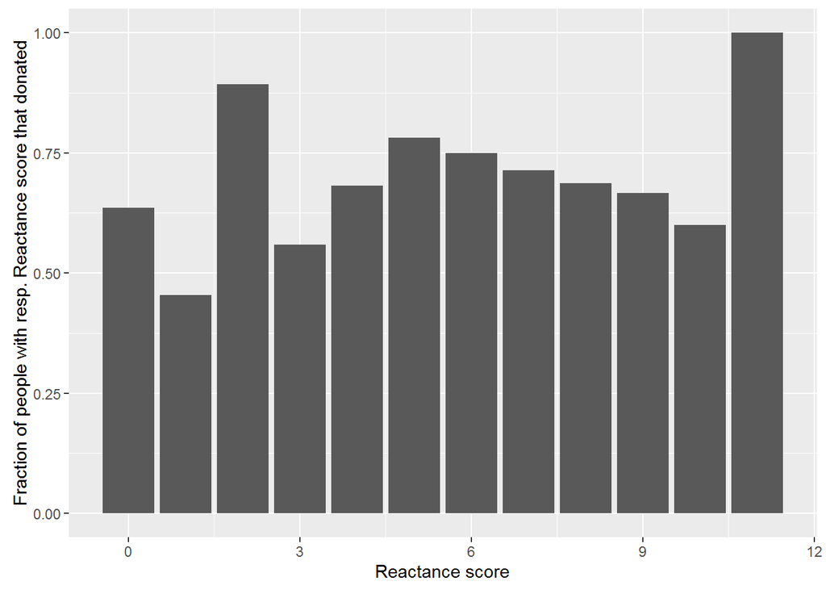

```
##
##  Pearson's Chi-squared test with simulated p-value (based on 2000
##  replicates)
##
## data:  table(df$Donated, df$Reactance)
## X-squared = 17.51, df = NA, p-value = 0.09945
```

```
##
## z test of coefficients:
##
##             Estimate Std. Error z value Pr(>|z|)
## (Intercept) 0.561536   0.277236  2.0255  0.04282 *
## Reactance   0.056777   0.058351  0.9730  0.33054
## ---
## Signif. codes:  0 '***' 0.001 '**' 0.01 '*' 0.05 '.' 0.1 ' ' 1
```

```
##
## z test of coefficients:
##
##                  Estimate Std. Error z value Pr(>|z|)
## (Intercept)      0.053315   0.441939  0.1206  0.90398
## treatmentRecNos  0.268721   0.526964  0.5099  0.61009
## treatmentDefNos -0.227599   0.510648 -0.4457  0.65581
## treatmentRecNap  0.489406   0.539125  0.9078  0.36400
## treatmentDefNap  0.665762   0.543882  1.2241  0.22092
## treatmentRecPol  0.937508   0.573486  1.6348  0.10210
## treatmentDefPol  1.261318   0.616728  2.0452  0.04084 *
## treatmentRecPar  0.692196   0.564019  1.2273  0.21973
## treatmentDefPar  0.826809   0.553354  1.4942  0.13513
## treatmentRecKno  0.470246   0.533924  0.8807  0.37846
## treatmentDefKno  0.253120   0.521714  0.4852  0.62756
## Reactance        0.064671   0.057734  1.1201  0.26265
## ---
## Signif. codes:  0 '***' 0.001 '**' 0.01 '*' 0.05 '.' 0.1 ' ' 1
```

```
##
## z test of coefficients:
##
##                                        Estimate Std. Error z value
## (Intercept)                            0.342504   0.465978  0.7350
## RecvsDefDDef                          -0.495061   0.513870 -0.9634
## SourcetypeNameAndPicture               0.221612   0.542153  0.4088
## SourcetypeKnowledgeable                0.203850   0.536709  0.3798
## SourcetypePolitical                    0.669043   0.576876  1.1598
## SourcetypePartisan                     0.422633   0.567976  0.7441
## Reactance                              0.059844   0.059954  0.9982
## RecvsDefDDef:SourcetypeNameAndPicture  0.669227   0.757139  0.8839
## RecvsDefDDef:SourcetypeKnowledgeable   0.277322   0.739348  0.3751
## RecvsDefDDef:SourcetypePolitical       0.816779   0.833587  0.9798
## RecvsDefDDef:SourcetypePartisan        0.632056   0.784803  0.8054
##                                       Pr(>|z|)
## (Intercept)                             0.4623
## RecvsDefDDef                            0.3353
## SourcetypeNameAndPicture                0.6827
## SourcetypeKnowledgeable                 0.7041
## SourcetypePolitical                     0.2461
## SourcetypePartisan                      0.4568
## Reactance                               0.3182
## RecvsDefDDef:SourcetypeNameAndPicture   0.3768
## RecvsDefDDef:SourcetypeKnowledgeable    0.7076
## RecvsDefDDef:SourcetypePolitical        0.3272
## RecvsDefDDef:SourcetypePartisan         0.4206
```

*The decision of whether or not to donate depends on Reactance (based on the Chi² Test. However the test is only slightly significant (p < .1). The logistic regression model with robust standard errors is not significant (without controlling for treatments). When controlling for treatments (including control), Reactance stays insignificant, and default with a political actor still significantly increases the probability to donate anything with control group as the base category. When including intervention type and source type as interactions (excluding control group), while controlling for reactance, nothing is significant (as before).*

### Decision to donate by Reactance score and treatment

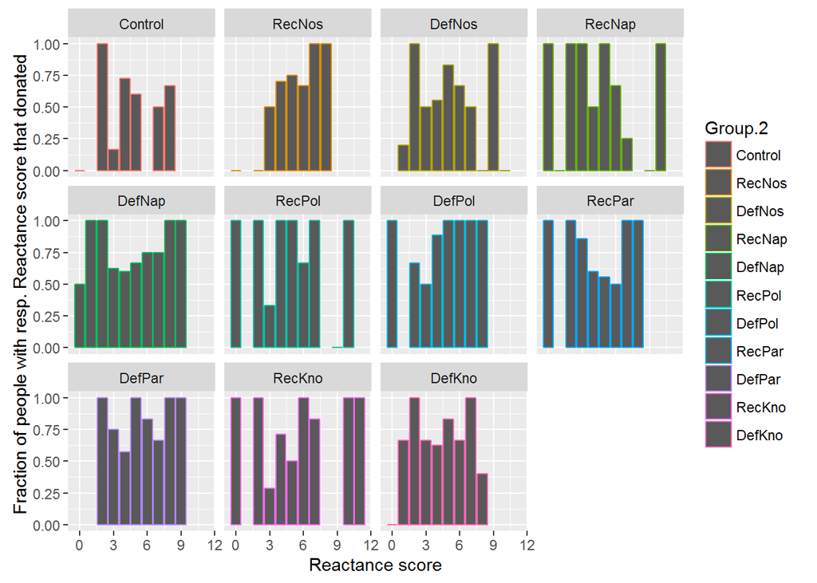

*Visually, there appears to be no relationship of reactance score and donation broken down by treatment on the decision to donate.*

### Decision to donate by EAI score

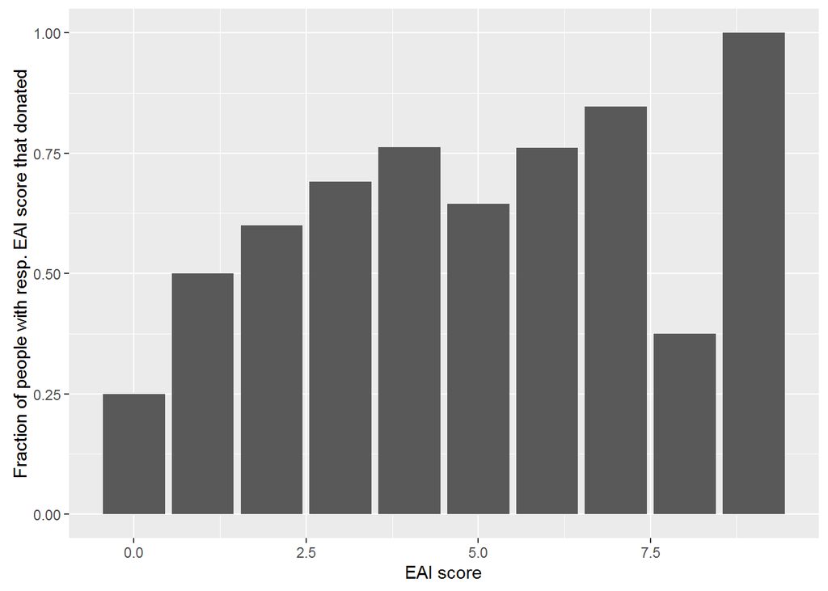

```
##
##  Pearson's Chi-squared test with simulated p-value (based on 2000
##  replicates)
##
## data:  table(df$Donated, df$EAI)
## X-squared = 17.998, df = NA, p-value = 0.03398
```

```
##
## z test of coefficients:
##
##             Estimate Std. Error z value Pr(>|z|)
## (Intercept)  0.22081    0.33035  0.6684  0.50388
## EAI          0.13224    0.07108  1.8604  0.06283 .
## ---
## Signif. codes:  0 '***' 0.001 '**' 0.01 '*' 0.05 '.' 0.1 ' ' 1
```

```
##
## z test of coefficients:
##
##                  Estimate Std. Error z value Pr(>|z|)
## (Intercept)     -0.368513   0.522593 -0.7052  0.48071
## treatmentRecNos  0.402222   0.535013  0.7518  0.45217
## treatmentDefNos -0.161328   0.519484 -0.3106  0.75614
## treatmentRecNap  0.641082   0.555192  1.1547  0.24821
## treatmentDefNap  0.712829   0.540887  1.3179  0.18754
## treatmentRecPol  1.023743   0.575561  1.7787  0.07529 .
## treatmentDefPol  1.277013   0.633031  2.0173  0.04366 *
## treatmentRecPar  0.852596   0.575552  1.4814  0.13851
## treatmentDefPar  0.832296   0.554692  1.5005  0.13349
## treatmentRecKno  0.542998   0.538692  1.0080  0.31346
## treatmentDefKno  0.332411   0.529576  0.6277  0.53021
## EAI              0.141437   0.075792  1.8661  0.06203 .
## ---
## Signif. codes:  0 '***' 0.001 '**' 0.01 '*' 0.05 '.' 0.1 ' ' 1
```

```
##
## z test of coefficients:
##
##                                        Estimate Std. Error z value
## (Intercept)                           -0.025038   0.487781 -0.0513
## RecvsDefDDef                          -0.573453   0.521768 -1.0991
## SourcetypeNameAndPicture               0.239706   0.548858  0.4367
## SourcetypeKnowledgeable                0.131265   0.541133  0.2426
## SourcetypePolitical                    0.616320   0.573737  1.0742
## SourcetypePartisan                     0.454242   0.567811  0.8000
## EAI                                    0.156457   0.080246  1.9497
## RecvsDefDDef:SourcetypeNameAndPicture  0.636693   0.761780  0.8358
## RecvsDefDDef:SourcetypeKnowledgeable   0.363668   0.749527  0.4852
## RecvsDefDDef:SourcetypePolitical       0.822078   0.847466  0.9700
## RecvsDefDDef:SourcetypePartisan        0.533158   0.788044  0.6766
##                                       Pr(>|z|)
## (Intercept)                            0.95906
## RecvsDefDDef                           0.27174
## SourcetypeNameAndPicture               0.66230
## SourcetypeKnowledgeable                0.80834
## SourcetypePolitical                    0.28272
## SourcetypePartisan                     0.42372
## EAI                                    0.05121 .
## RecvsDefDDef:SourcetypeNameAndPicture  0.40327
## RecvsDefDDef:SourcetypeKnowledgeable   0.62754
## RecvsDefDDef:SourcetypePolitical       0.33203
## RecvsDefDDef:SourcetypePartisan        0.49869
## ---
## Signif. codes:  0 '***' 0.001 '**' 0.01 '*' 0.05 '.' 0.1 ' ' 1
```

*The decision of whether or not to donate depends on EAI (based on the Chi² Test). The test is significant (p < .05). In the logistic regression model with robust standard errors EAI is significantly positive (without controlling for treatments). When controlling for treatments (including control), EAI stays significant (but only at p < .1), and recommendation and default with a political actor still significantly increase the probability to donate anything with control group as the base category. When including intervention type and source type as interactions (excluding control group), while controlling for EAI, only EAI is significantly positive (but only at p < .1).*

### Decision to donate by EAI score and treatment

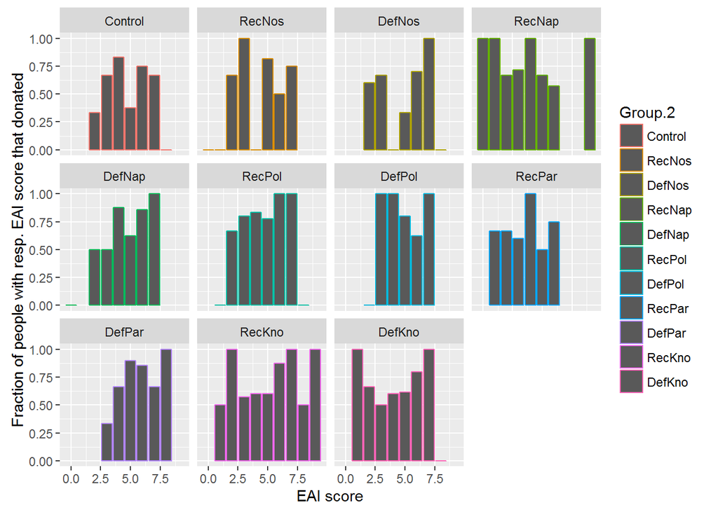

*Visually, there appears to be some positive relationship of EAI score and donation broken down by treatment on the decision to donate. However, it is hard to verify visually.*

## Variable: Beliefs about other participants donations

### Aggregated descriptive statistics

```
##    Min. 1st Qu.  Median    Mean 3rd Qu.    Max.
##   0.000   1.000   2.000   1.973   3.000   7.000
```

```
## [1] 1.05609
```

### Distribution of aggregated beliefs about donations

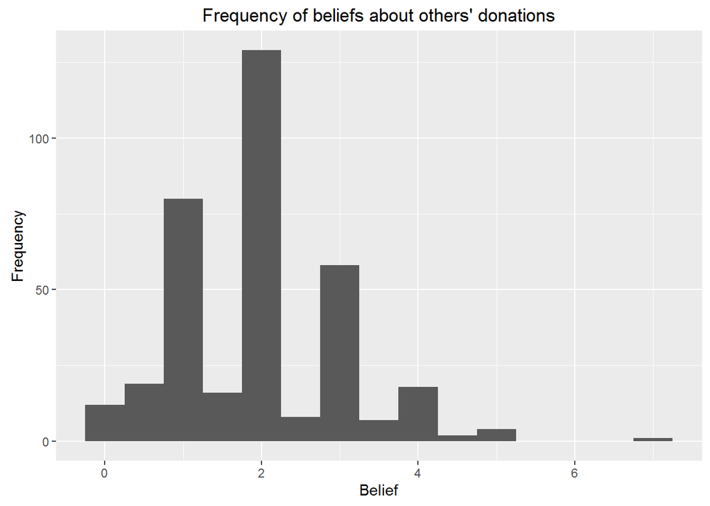

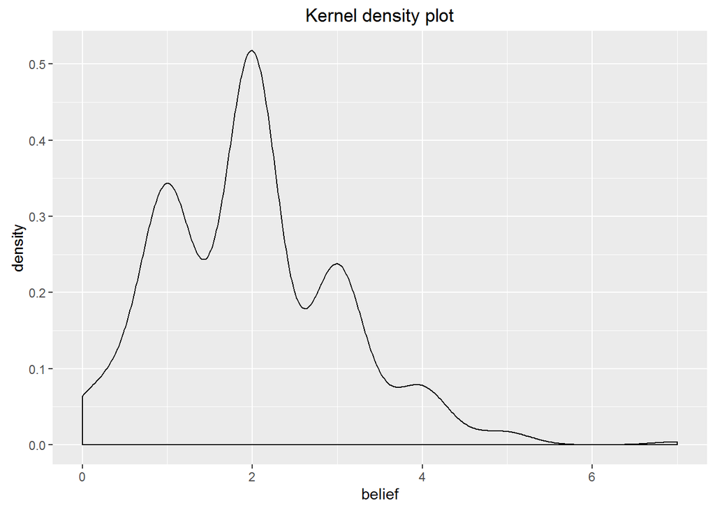

#### Distribution of beliefs by treatment

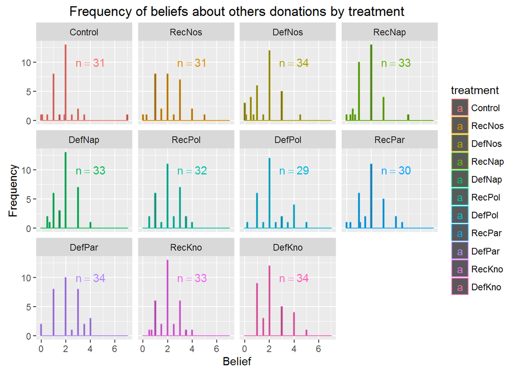

### Beliefs by treatment (Boxplot)

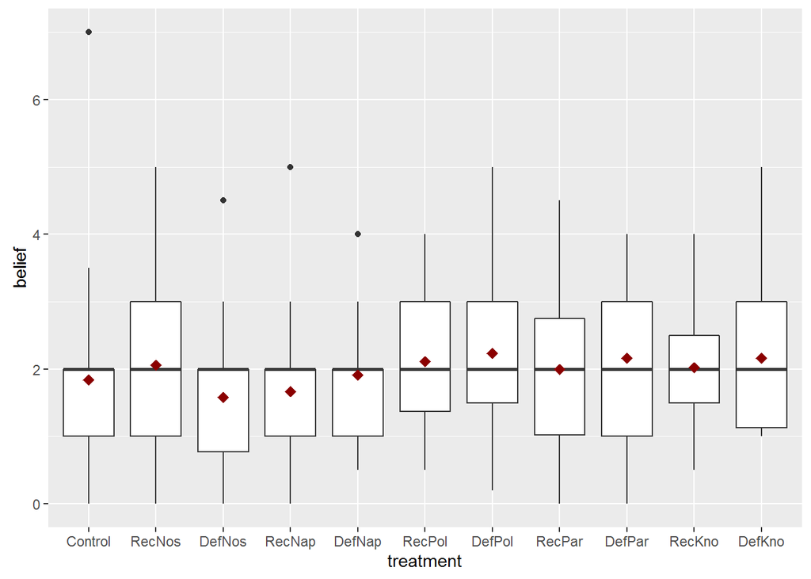

```
##
##  Kruskal-Wallis rank sum test
##
## data:  df$belief by df$treatment
## Kruskal-Wallis chi-squared = 14.128, df = 10, p-value = 0.1672
```

*There do not appear to be differences in the median beliefs about other participants donations between the different treatments. The Kruskal Wallis test supports this view and does not reject the null hypothesis of equal median beliefs between the different treatments.*

# Test of hypotheses from the working paper

## H0a

> Mean and median payments to retire carbon licenses in the control condition are (close to) zero.

*H0: Average Donations = 0*

*HA: Average Donations >< 0*

```
##
##  Wilcoxon signed rank test with continuity correction
##
## data:  df$Donation
## V = 30135, p-value < 2.2e-16
## alternative hypothesis: true location is not equal to 0
```

*Based on the Wilcoxon test we reject the null that Donations are equal to 0. Note however that the test almost rejects any value. This is possibly because of the metric nature of the Donation variable.*

## H0b

> The share of subjects whose payments correspond to the recommended, respectively defaulted payment-value (convergence) is higher than in the control condition. Additionally, we expect that the share of subjects converging to the default is higher than the share converging to the recommendation.

### Aggregated donations in recommendation treatments > donations in control group

```
##
##  Kruskal-Wallis rank sum test
##
## data:  df$Donation and df$RecvsDef
## Kruskal-Wallis chi-squared = 0.81529, df = 2, p-value = 0.6652
```

*Based on the Kruskal Wallis test we do not reject the null hypothesis that donations do not significantly differ between groups that get a recommendation, a default, or ar in the control group.*

### Aggregated donations in default treatments > donations in recommendation treatments

```
##
##  Wilcoxon rank sum test with continuity correction
##
## data:  df$Donation by df$RecvsDefD
## W = 12914, p-value = 0.4402
## alternative hypothesis: true location shift is less than 0
```

*Based on the one-sided Wilcoxon test we do not reject the null that Donations in default treatments are equal to donations in recommendation treatments.*

## H0c

> The share of subjects converging to the recommended, respectively defaulted payment-values in the name and picture condition is higher than in the neutral source-condition.

### For Recommendations: Donations in Name and Picture treatments > Donations in No-Source treatments

```
##
##  Wilcoxon rank sum test with continuity correction
##
## data:  df$Donation by df$RecNapvsRecNos
## W = 546, p-value = 0.3186
## alternative hypothesis: true location shift is greater than 0
```

*Based on the Wilcoxon test we do not reject the null hypothesis that Donations in recommendation treatments informing about the name and picture of the source are equal to donations in recommendation treatments providing no information about the source of the recommendation.*

### For Defaults: Donations in Name and Picture treatments > Donations in No-Source treatments

```
##
##  Wilcoxon rank sum test with continuity correction
##
## data:  df$Donation by df$DefNapvsDefNos
## W = 656, p-value = 0.1106
## alternative hypothesis: true location shift is greater than 0
```

*Based on the Wilcoxon test we do not reject the null hypothesis that Donations in default treatments informing about the name and picture of the source are equal to donations in default treatments providing no information about the source of the default.*

## H1

> A subject’s reaction towards the respective intervention depends on is predicted by trait reactance.

**This is an interaction**

```
##
## t test of coefficients:
##
##                            Estimate Std. Error t value Pr(>|t|)
## (Intercept)                0.687929   0.452557  1.5201 0.129439
## treatmentRecNos           -0.620804   0.815451 -0.7613 0.447018
## treatmentDefNos            1.486857   0.895903  1.6596 0.097935 .
## treatmentRecNap            1.192660   0.918193  1.2989 0.194873
## treatmentDefNap            0.184938   0.585180  0.3160 0.752174
## treatmentRecPol            0.733730   0.659930  1.1118 0.267016
## treatmentDefPol            1.207244   0.897859  1.3446 0.179679
## treatmentRecPar            1.892071   0.729399  2.5940 0.009907 **
## treatmentDefPar            1.634085   0.866232  1.8864 0.060110 .
## treatmentRecKno           -0.845384   0.823118 -1.0271 0.305144
## treatmentDefKno            1.334843   0.834214  1.6001 0.110523
## Reactance                  0.105147   0.102654  1.0243 0.306449
## treatmentRecNos:Reactance  0.167178   0.197007  0.8486 0.396723
## treatmentDefNos:Reactance -0.271008   0.151182 -1.7926 0.073947 .
## treatmentRecNap:Reactance -0.228210   0.192929 -1.1829 0.237707
## treatmentDefNap:Reactance  0.016878   0.136238  0.1239 0.901478
## treatmentRecPol:Reactance -0.064957   0.143480 -0.4527 0.651042
## treatmentDefPol:Reactance -0.165147   0.168957 -0.9774 0.329059
## treatmentRecPar:Reactance -0.320347   0.150351 -2.1307 0.033851 *
## treatmentDefPar:Reactance -0.245703   0.166017 -1.4800 0.139826
## treatmentRecKno:Reactance  0.171704   0.197727  0.8684 0.385811
## treatmentDefKno:Reactance -0.196808   0.156374 -1.2586 0.209067
## ---
## Signif. codes:  0 '***' 0.001 '**' 0.01 '*' 0.05 '.' 0.1 ' ' 1
```

```
##
## t test of coefficients:
##
##                                                  Estimate Std. Error
## (Intercept)                                      0.067125   0.678263
## RecvsDefDDef                                     2.107661   1.028460
## SourcetypeNameAndPicture                         1.813464   1.047930
## SourcetypeKnowledgeable                         -0.224581   0.965734
## SourcetypePolitical                              1.354533   0.831074
## SourcetypePartisan                               2.512875   0.887230
## Reactance                                        0.272324   0.168128
## RecvsDefDDef:SourcetypeNameAndPicture           -3.115383   1.354046
## RecvsDefDDef:SourcetypeKnowledgeable             0.072566   1.421730
## RecvsDefDDef:SourcetypePolitical                -1.634147   1.374616
## RecvsDefDDef:SourcetypePartisan                 -2.365646   1.389347
## RecvsDefDDef:Reactance                          -0.438186   0.201450
## SourcetypeNameAndPicture:Reactance              -0.395387   0.234402
## SourcetypeKnowledgeable:Reactance                0.004526   0.238366
## SourcetypePolitical:Reactance                   -0.232135   0.195738
## SourcetypePartisan:Reactance                    -0.487524   0.200827
## RecvsDefDDef:SourcetypeNameAndPicture:Reactance  0.683274   0.274372
## RecvsDefDDef:SourcetypeKnowledgeable:Reactance   0.069674   0.288175
## RecvsDefDDef:SourcetypePolitical:Reactance       0.337996   0.261978
## RecvsDefDDef:SourcetypePartisan:Reactance        0.512830   0.263944
##                                                 t value Pr(>|t|)
## (Intercept)                                      0.0990 0.921230
## RecvsDefDDef                                     2.0493 0.041290 *
## SourcetypeNameAndPicture                         1.7305 0.084556 .
## SourcetypeKnowledgeable                         -0.2325 0.816268
## SourcetypePolitical                              1.6299 0.104170
## SourcetypePartisan                               2.8323 0.004932 **
## Reactance                                        1.6197 0.106328
## RecvsDefDDef:SourcetypeNameAndPicture           -2.3008 0.022082 *
## RecvsDefDDef:SourcetypeKnowledgeable             0.0510 0.959327
## RecvsDefDDef:SourcetypePolitical                -1.1888 0.235448
## RecvsDefDDef:SourcetypePartisan                 -1.7027 0.089649 .
## RecvsDefDDef:Reactance                          -2.1752 0.030391 *
## SourcetypeNameAndPicture:Reactance              -1.6868 0.092673 .
## SourcetypeKnowledgeable:Reactance                0.0190 0.984863
## SourcetypePolitical:Reactance                   -1.1859 0.236573
## SourcetypePartisan:Reactance                    -2.4276 0.015782 *
## RecvsDefDDef:SourcetypeNameAndPicture:Reactance  2.4903 0.013299 *
## RecvsDefDDef:SourcetypeKnowledgeable:Reactance   0.2418 0.809117
## RecvsDefDDef:SourcetypePolitical:Reactance       1.2902 0.197975
## RecvsDefDDef:SourcetypePartisan:Reactance        1.9429 0.052948 .
## ---
## Signif. codes:  0 '***' 0.001 '**' 0.01 '*' 0.05 '.' 0.1 ' ' 1
```

*If I interpret this hypothesis as reactance interacting with the treatment on the donation amount, there appears to be an effect of reactance on the treatment, also when treatments are broken down to the two factors sourcetype and intervention type (excluding the control group). The OLS-regression model uses robust standard errors and, remember, treats reactance as a metric variables.*

*Mind that it might be roblematic that there are not many observations in each respective category, so that the significant effects might be due to missing observations (?). I suspect this because the significant effects are missing as soon as I do not use reactance as part of an interaction. I should investigate this further.*

### H1a

> A subject that scores high (i.e. higher than median) on trait reactance is less likely to converge to the recommended and defaulted payment-values, than a subject scoring low on trait reactance.

**This is an interaction**

*The previous regression suggests that as reactance increases, the significantly positive effect of default vs. recommendation decreases. Note however that I am not quite sure if it is right to treat this as a tripple interaction term. Below, I do not do that, but only control for sourcetype when interacting the intervention type with the reactance dummy.*

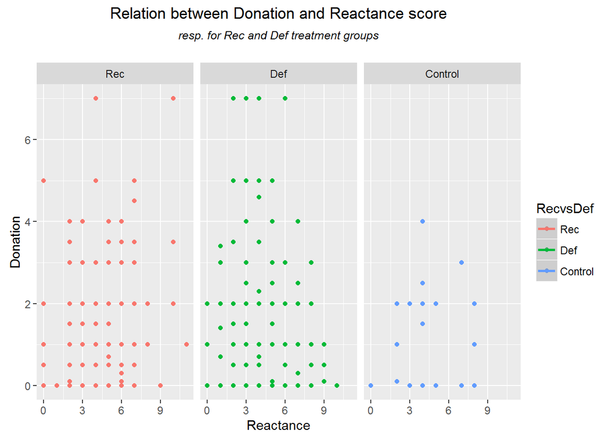

```
##
##  Wilcoxon rank sum test with continuity correction
##
## data:  df$Donation[df$treatment != "Control"] by df$ReactD[df$treatment != "Control"]
## W = 12605, p-value = 0.6095
## alternative hypothesis: true location shift is greater than 0
```

*Based on the (one-sided) Wilcoxon test we can not reject the null hypothesis of a location shift of the donation amount equal to zero of those with an above vs. below/equal median reactance score, among those that encountered either type of intervention (aggregated over/ irrespective of sourcetype).*

### H1b

> A subject that scores high (i.e. higher than median) on trait reactance is less likely to converge to the defaulted than to the recommended payment-value.

```
##
##  Wilcoxon rank sum test with continuity correction
##
## data:  df$Donation[df$ReactD == "Above Med React"] by df$RecvsDefD[df$ReactD == "Above Med React"]
## W = 2420.5, p-value = 0.606
## alternative hypothesis: true location shift is greater than 0
```

```
##
## t test of coefficients:
##
##                                      Estimate Std. Error t value  Pr(>|t|)
## (Intercept)                         1.2634519  0.2312768  5.4629 9.523e-08
## SourcetypeNameAndPicture            0.0138549  0.2702536  0.0513    0.9591
## SourcetypeKnowledgeable             0.0688528  0.2924089  0.2355    0.8140
## SourcetypePolitical                 0.2881925  0.2926199  0.9849    0.3254
## SourcetypePartisan                  0.3358988  0.3152896  1.0654    0.2875
## RecvsDefDDef                        0.2127526  0.2497677  0.8518    0.3950
## ReactDAbove Med React              -0.0030185  0.2293560 -0.0132    0.9895
## RecvsDefDDef:ReactDAbove Med React -0.1719655  0.3529273 -0.4873    0.6264
##
## (Intercept)                        ***
## SourcetypeNameAndPicture
## SourcetypeKnowledgeable
## SourcetypePolitical
## SourcetypePartisan
## RecvsDefDDef
## ReactDAbove Med React
## RecvsDefDDef:ReactDAbove Med React
## ---
## Signif. codes:  0 '***' 0.001 '**' 0.01 '*' 0.05 '.' 0.1 ' ' 1
```

```
##
## t test of coefficients:
##
##                                                             Estimate
## (Intercept)                                                  1.05000
## SourcetypeNameAndPicture                                     0.48529
## SourcetypeKnowledgeable                                     -0.28529
## SourcetypePolitical                                          0.47941
## SourcetypePartisan                                           1.16875
## RecvsDefDDef                                                 0.69211
## ReactDAbove Med React                                        0.52273
## SourcetypeNameAndPicture:RecvsDefDDef                       -1.05740
## SourcetypeKnowledgeable:RecvsDefDDef                         0.26819
## SourcetypePolitical:RecvsDefDDef                            -0.47152
## SourcetypePartisan:RecvsDefDDef                             -1.16086
## SourcetypeNameAndPicture:ReactDAbove Med React              -0.96427
## SourcetypeKnowledgeable:ReactDAbove Med React                0.34382
## SourcetypePolitical:ReactDAbove Med React                   -0.37214
## SourcetypePartisan:ReactDAbove Med React                    -1.67005
## RecvsDefDDef:ReactDAbove Med React                          -1.24483
## SourcetypeNameAndPicture:RecvsDefDDef:ReactDAbove Med React  2.20868
## SourcetypeKnowledgeable:RecvsDefDDef:ReactDAbove Med React   0.13107
## SourcetypePolitical:RecvsDefDDef:ReactDAbove Med React       0.78869
## SourcetypePartisan:RecvsDefDDef:ReactDAbove Med React        2.18501
##                                                             Std. Error
## (Intercept)                                                    0.26800
## SourcetypeNameAndPicture                                       0.45209
## SourcetypeKnowledgeable                                        0.33558
## SourcetypePolitical                                            0.42386
## SourcetypePartisan                                             0.51918
## RecvsDefDDef                                                   0.63304
## ReactDAbove Med React                                          0.57504
## SourcetypeNameAndPicture:RecvsDefDDef                          0.76653
## SourcetypeKnowledgeable:RecvsDefDDef                           0.82659
## SourcetypePolitical:RecvsDefDDef                               0.83971
## SourcetypePartisan:RecvsDefDDef                                0.89238
## SourcetypeNameAndPicture:ReactDAbove Med React                 0.73108
## SourcetypeKnowledgeable:ReactDAbove Med React                  0.76663
## SourcetypePolitical:ReactDAbove Med React                      0.73640
## SourcetypePartisan:ReactDAbove Med React                       0.80309
```

[output cut: 34 more lines]

```
## SourcetypeNameAndPicture:RecvsDefDDef                       0.1687690
## SourcetypeKnowledgeable:RecvsDefDDef                        0.7458203
## SourcetypePolitical:RecvsDefDDef                            0.5748577
## SourcetypePartisan:RecvsDefDDef                             0.1942978
## SourcetypeNameAndPicture:ReactDAbove Med React              0.1881782
## SourcetypeKnowledgeable:ReactDAbove Med React               0.6541299
## SourcetypePolitical:ReactDAbove Med React                   0.6136826
## SourcetypePartisan:ReactDAbove Med React                    0.0384089 *
## RecvsDefDDef:ReactDAbove Med React                          0.1623213
## SourcetypeNameAndPicture:RecvsDefDDef:ReactDAbove Med React 0.0414254 *
## SourcetypeKnowledgeable:RecvsDefDDef:ReactDAbove Med React  0.9121878
## SourcetypePolitical:RecvsDefDDef:ReactDAbove Med React      0.4828515
## SourcetypePartisan:RecvsDefDDef:ReactDAbove Med React       0.0791168 .
## ---
## Signif. codes:  0 '***' 0.001 '**' 0.01 '*' 0.05 '.' 0.1 ' ' 1
```

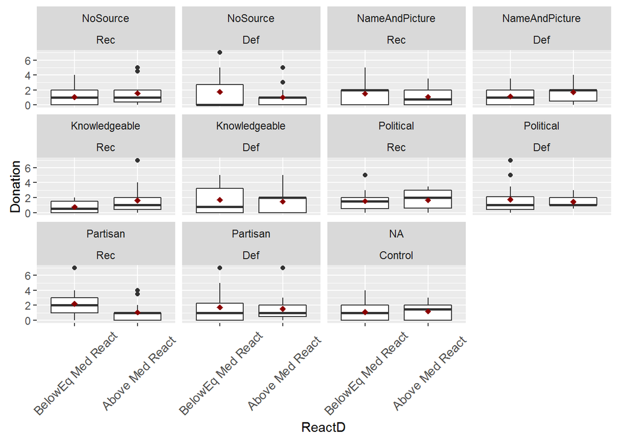

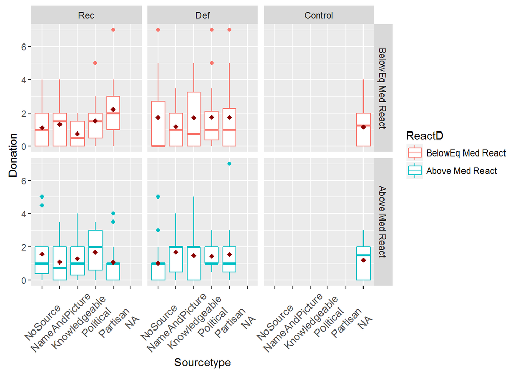

*The OLS regression with robust standard errors suggests that there is no interaction effect between having above median reactance score and the default on donation amount. When including the tripple interaction with Sourcetype and Intervention type some parameters become significant, but this could be due to the same problem of not many observations per category as above. Judged by the latter figure, there might be an interaction for recommendation instrument when switching from political to partisan source information with reactance above/ or below median. For recommendations, switching from political to partisan source information increases average/median donation amounts for those with below or equal to median reactance, and decreases average/median donation amounts for those with above median reactance. This and other interaction effects are appearent in the triple interaction robust OLS regression above.*

## H2

> The share of subjects converging to the recommended, respectively defaulted payment-values in the condition informing about the academic degree of the source is higher than in the name and picture condition.

### For Recommendations: Donations in Knowledge treatments > Donations in Name and Picture treatments

```r
wilcox.test(df$Donation ~ df$RecNapvsRecKno, exact = FALSE, alternative = "less")
```

```
##
##  Wilcoxon rank sum test with continuity correction
##
## data:  df$Donation by df$RecNapvsRecKno
## W = 593, p-value = 0.7407
## alternative hypothesis: true location shift is less than 0
```

*Based on the Wilcoxon test we cannot confidently reject the null hypothesis of zero donation location shift between recommendation groups with name and picture information vs. recommendation groups with knowledge source information in favor of the alternative hypothesis that the former are less than the latter.*

### For Defaults: Donations in Knowledge treatments > Donations in Name and Picture treatments

```r
wilcox.test(df$Donation ~ df$DefNapvsDefKno, exact = FALSE, alternative = "less")
```

```
##
##  Wilcoxon rank sum test with continuity correction
##
## data:  df$Donation by df$DefNapvsDefKno
## W = 557.5, p-value = 0.4846
## alternative hypothesis: true location shift is less than 0
```

*Based on the Wilcoxon test we cannot confidently reject the null hypothesis of zero donation location shift between default groups with name and picture information vs. default groups with knowledge source information in favor of the alternative hypothesis that the former are less than the latter.*

## H3-1

> The share of subjects converging to the recommended, respectively defaulted payment-values in the condition informing about the political characteristic of the source is lower than in the name and picture condition.

### For Recommendations: Donations in Political treatments < Donations in Name and Picture treatments

```r
wilcox.test(df$Donation ~ df$RecNapvsRecPol, exact = FALSE, alternative = "greater")
```

```
##
##  Wilcoxon rank sum test with continuity correction
##
## data:  df$Donation by df$RecNapvsRecPol
## W = 458, p-value = 0.8281
## alternative hypothesis: true location shift is greater than 0
```

*Based on the one sided Wilcoxon test we cannot reject the null hypothesis that Donations in recommendation treatments informing about the political mandate of the source are equal to donations in recommendations treatments providing the name and picture of the source, in favor of the alternative hypothesis that donations in recommendation + political mandate groups are less than those in the recommendation + name and picture groups.*

### For Defaults: Donations in Political treatments < Donations in Name and Picture treatments

```r
wilcox.test(df$Donation ~ df$DefNapvsDefPol, exact = FALSE, alternative = "greater")
```

```
##
##  Wilcoxon rank sum test with continuity correction
##
## data:  df$Donation by df$DefNapvsDefPol
## W = 466.5, p-value = 0.5712
## alternative hypothesis: true location shift is greater than 0
```

*Based on the one sided Wilcoxon test cannot reject the null that donations in default treatments informing about the political mandate of the source are equal to donations in default treatments providing the name and picture of the source, in favor of the alternative hypothesis that donations in default + political mandate groups are less than those in the default + name and picture groups.*

## H3-2

> When the source is political the share of subjects converging to the default is lower than the share of subjects converging to the recommendation.

### Donations in default treatments informing about the political characteristics of the source < donations in recommendation treatments informing about the political characteristics of the source

```r
wilcox.test(df$Donation ~ df$RecPolvsDefPol, exact = FALSE, alternative = "greater")
```

```
##
##  Wilcoxon rank sum test with continuity correction
##
## data:  df$Donation by df$RecPolvsDefPol
## W = 486, p-value = 0.3765
## alternative hypothesis: true location shift is greater than 0
```

*Based on the one sided Wilcoxon test we cannot reject the null that donations in default treatments informing about the political characteristics of the source are equal to donations in recommendation treatments informing about the political characteristics of the source, in favor of the alternative hypothesis that donations are higher in the political recommendation groups than in the political default groups.*

### H3a

> A subject that scores high on trust in politics is more likely to converge to the recommended and defaulted payment-values, than a subject scoring low on trust in politics. *In treatments informing about the political characteristics of the source.*

**This is an interaction effect**

```
##
##     Control RecNos DefNos RecNap DefNap RecPol DefPol RecPar DefPar RecKno
##   0      10     11      9     16     13     10     11     14     15     14
##   1      11     13     12      9     14     16     12     11     11     16
##   2       8      7      8      7      6      6      6      4      5      2
##   3       1      0      4      1      0      0      0      1      3      1
##   4       1      0      1      0      0      0      0      0      0      0
##
##     DefKno
##   0     15
##   1     14
##   2      3
##   3      2
##   4      0
```

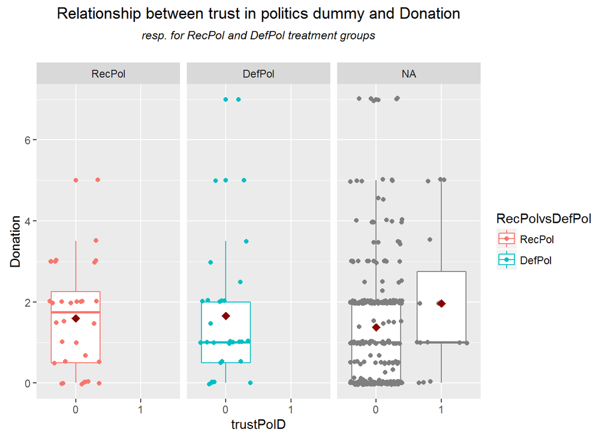

*Problem is that there are not enough observations with high trust in politics (no observation in DefPol and RecPol treatment.*

*Therefore we are not able to test this hypothesis with this variable! In the following, I construct a different dummy variable with respect to deviation from the median value.*

#### H3a - alternative with differently coded variable (above median)

```
##
##                        Control RecNos DefNos RecNap DefNap RecPol DefPol
##   BelowEq Med PolTrust      21     24     21     25     27     26     23
##   Above Med PolTrust        10      7     13      8      6      6      6
##
##                        RecPar DefPar RecKno DefKno
##   BelowEq Med PolTrust     25     26     30     29
##   Above Med PolTrust        5      8      3      5
```

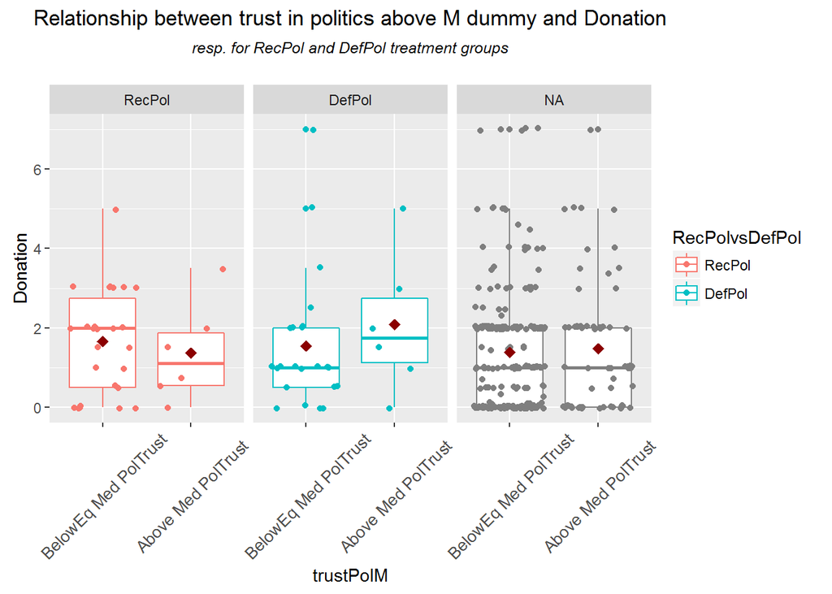

```
##
##  Wilcoxon rank sum test with continuity correction
##
## data:  df$Donation[df$treatment == "RecPol"] by df$trustPolM[df$treatment == "RecPol"]
## W = 86.5, p-value = 0.6708
## alternative hypothesis: true location shift is less than 0
```

```
##
##  Wilcoxon rank sum test with continuity correction
##
## data:  df$Donation[df$treatment == "DefPol"] by df$trustPolM[df$treatment == "DefPol"]
## W = 51.5, p-value = 0.175
## alternative hypothesis: true location shift is less than 0
```

```
##
## t test of coefficients:
##
##                                                  Estimate Std. Error
## (Intercept)                                       1.65385    0.26056
## RecPolvsDefPolDefPol                             -0.11037    0.44073
## trustPolMAbove Med PolTrust                      -0.28718    0.55380
## RecPolvsDefPolDefPol:trustPolMAbove Med PolTrust  0.82703    0.94082
##                                                  t value  Pr(>|t|)
## (Intercept)                                       6.3473 3.858e-08 ***
## RecPolvsDefPolDefPol                             -0.2504    0.8032
## trustPolMAbove Med PolTrust                      -0.5186    0.6061
## RecPolvsDefPolDefPol:trustPolMAbove Med PolTrust  0.8791    0.3831
## ---
## Signif. codes:  0 '***' 0.001 '**' 0.01 '*' 0.05 '.' 0.1 ' ' 1
```

*The one sided Wilcoxon tests suggest that there is no effect of having trust above median neither for those in the RecPol, nor for those in the DefPol treatment groups. I think this does not exclude a possible interaction effect per se, but the OLS regression suggests that, among political sources, there is no significant interaction effect of above median trust in politics and receiving a recommendation vs. default by a political actor on donation amount.*

### H3b

> A subject that values conformity, i.e. doing what the majority does, is more likely to converge to the recommended and defaulted payment-values, than a subject that does not value conformity.

```
##
##     Control RecNos DefNos RecNap DefNap RecPol DefPol RecPar DefPar RecKno
##   0      15      7     16     20     16     14     10     14     19     12
##   1       9     20     12      9     14     12     15     10     13     15
##   2       6      4      5      4      2      3      3      5      0      5
##   3       0      0      1      0      1      3      1      1      2      1
##   4       1      0      0      0      0      0      0      0      0      0
##
##     DefKno
##   0     21
##   1     10
##   2      2
##   3      1
##   4      0
```

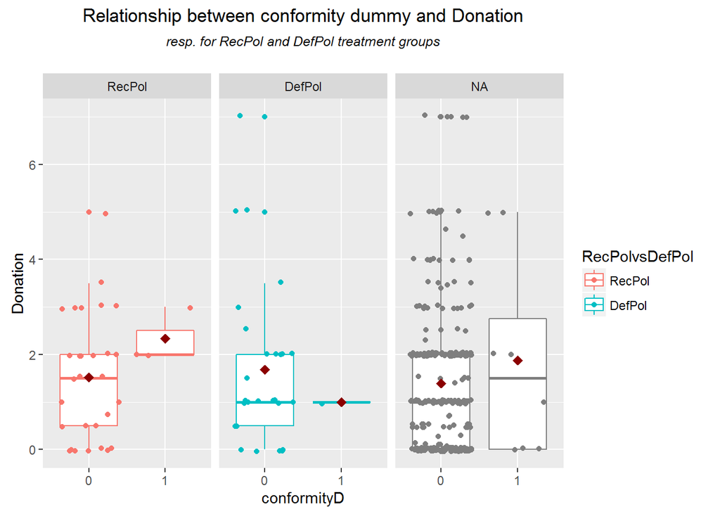

```
##
##  Wilcoxon rank sum test with continuity correction
##
## data:  df$Donation by df$conformityD
## W = 1696, p-value = 0.2961
## alternative hypothesis: true location shift is not equal to 0
```

*Therefore we are not able to test this hypothesis! In the following, I construct a different dummy variable with respect to deviation from the median value.*

#### H3b - alternative with differently coded variable (above median)

```
##
##                          Control RecNos DefNos RecNap DefNap RecPol DefPol
##   BelowEq Med Conformity      24     27     28     29     30     26     25
##   Above Med Conformity         7      4      6      4      3      6      4
##
##                          RecPar DefPar RecKno DefKno
##   BelowEq Med Conformity     24     32     27     31
##   Above Med Conformity        6      2      6      3
```

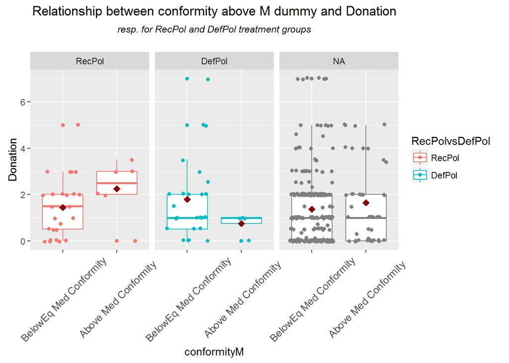

```
##
##  Wilcoxon rank sum test with continuity correction
##
## data:  df$Donation[df$treatment == "RecPol"] by df$conformityM[df$treatment == "RecPol"]
## W = 46, p-value = 0.06091
## alternative hypothesis: true location shift is less than 0
```

```
##
##  Wilcoxon rank sum test with continuity correction
##
## data:  df$Donation[df$treatment == "DefPol"] by df$conformityM[df$treatment == "DefPol"]
## W = 68, p-value = 0.8839
## alternative hypothesis: true location shift is less than 0
```

```
##
## t test of coefficients:
##
##                                                      Estimate Std. Error
## (Intercept)                                           1.45000    0.25266
## RecPolvsDefPolDefPol                                  0.35000    0.43750
## conformityMAbove Med Conformity                       0.80000    0.54584
## RecPolvsDefPolDefPol:conformityMAbove Med Conformity -1.85000    0.68969
##                                                      t value  Pr(>|t|)
## (Intercept)                                           5.7389 3.835e-07 ***
## RecPolvsDefPolDefPol                                  0.8000  0.427029
## conformityMAbove Med Conformity                       1.4656  0.148242
## RecPolvsDefPolDefPol:conformityMAbove Med Conformity -2.6824  0.009548 **
## ---
## Signif. codes:  0 '***' 0.001 '**' 0.01 '*' 0.05 '.' 0.1 ' ' 1
```

**IMPORTANT: How to correctly interpret the interaction effect when the main effect is not significant?**

*“There is only one situation possible in which a interaction is significant, but the main effects are not: a cross-over interaction.” This cross-interaction is appearant in the box plot. I can imagine the main effect as the difference of the mean of the left means of RecPol and DefPol and the mean of the right means of RecPol and DefPol. This would be the main effect of conformity. This is equivalent for the other main effect.*

**IMPORTANT: Do I need to incorporate the other groups, i.e. the mean effect of conformity over all other treatments?**